# correlate-mirnas

## correlate-mirnas

*Last modified 11:03 PM on Nov 25, 2014. This document, R session image, knitr cache, figures, and other associated datasets are located in `cruncher:/inside/grotto/blin/trna-markers/correlate-mirnas/`.*

```r
library(DESeq2)
library(BiocParallel)
library(reshape2)
library(ggplot2)
library(stringr)
register(MulticoreParam(8)) # turn this off depending on your machine!
load('/inside/grotto/blin/trna-markers/feature-counts/feature-counts.RData')
```

From feature-counts, we have four count matrices: `hg19_feature_nt_counts`, `hg19_feature_tp_counts`, `trna_nt_counts`, and `trna_tp_counts`. We are interested in correlations for the hg19 feature counts, since that's where the tRF counts are.

### Normalize counts

```r
hg19_feature_counts <- cbind(hg19_feature_tp_counts, hg19_feature_nt_counts)
hg19_feature_counts <- hg19_feature_counts[apply(hg19_feature_counts, 1, function(row) length(which(row > 0)) > 5), ]
hg19_feature_counts <- hg19_feature_counts[apply(hg19_feature_counts, 1, function(row) sum(row) > 10), ]
num_pairs <- length(colnames(hg19_feature_counts))/2
colData <- data.frame(row.names = colnames(hg19_feature_counts), condition = c(rep("tp", num_pairs), rep("nt", num_pairs)), type = "single-read")
dds <- DESeqDataSetFromMatrix(countData = hg19_feature_counts, colData = colData, design = ~ condition)
dds <- DESeq(dds)
res <- results(dds)
```

We don't need to run the entire DESeq analysis pipeline. The only thing of interest is the scaling factors which we can now apply to our hg19 feature counts.

```r
normalized_counts <- t(t(hg19_feature_counts) / sizeFactors(dds)) # R applies vectors on columns (genes), we want R to apply them on rows (samples) for size factors
```

We should confirm that the normalization did a good job by making an MA plot.

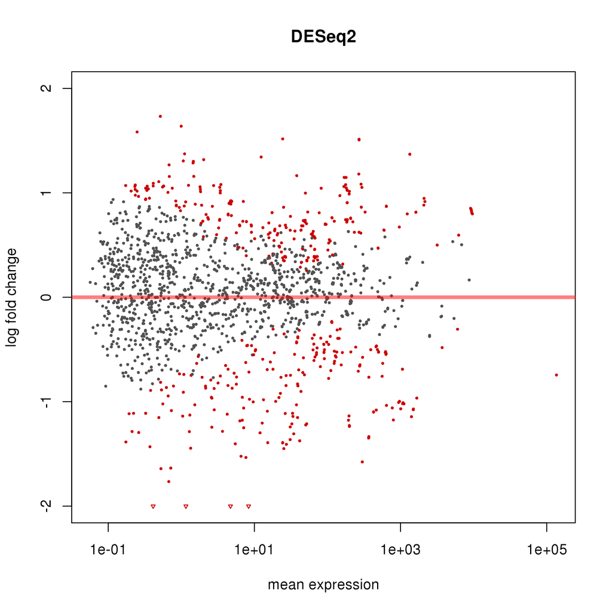

```r
plotMA(res, main = "DESeq2", ylim = c(-2, 2))
```

### Correlation

The correlation will be performed on a matrix of fold changes. I'm not sure whether I should take the log<sub>2</sub> fold change before then. I do in this case, to minimize heteroscedasticity - reduce the variability between sub-populations, which in this case is individual genes or groups of genes. Since these are `log2` values, and there are fragments with counts of 0, we will use Laplacian smoothing (add a pseudocount of 1) to avoid `-Inf` values.

```r
# NT normalized counts - TP normalized counts
fold_changes <- log2(normalized_counts[, (num_pairs+1):(num_pairs*2)]+1) - log2(normalized_counts[, 1:num_pairs]+1)
```

I also have to choose between Pearson's r and Spearman's \(\rho\). Apparently, Pearson's r has more power and finds linear (as opposed to monotonic) relationships, so I'll start with that.

```r
correlations <- cor(t(fold_changes), method = "pearson") # function operates on columns, so need to get features onto columns.
```

```r
mir_corr <- correlations[!str_detect(colnames(correlations), "hsa"), str_detect(colnames(correlations), "hsa")] # isolate for miRNAs
mir_corr_df <- melt(mir_corr)
colnames(mir_corr_df) <- c("Feature", "miRNA", "r")
mir_corr_df <- mir_corr_df[order(mir_corr_df$r, decreasing = TRUE), ]
#mirnas <- colnames(mir_corr)
#mir_corr <- lapply(1:ncol(mir_corr), function(mirna_column) mir_corr[, mirna_column][order(mir_corr[, mirna_column], decreasing = TRUE)]) # sort correlation matrix. This line is convoluted because *apply removes row names upon return, and we need to preserve the row names (feature identifiers).
#names(mir_corr) <- mirnas
```

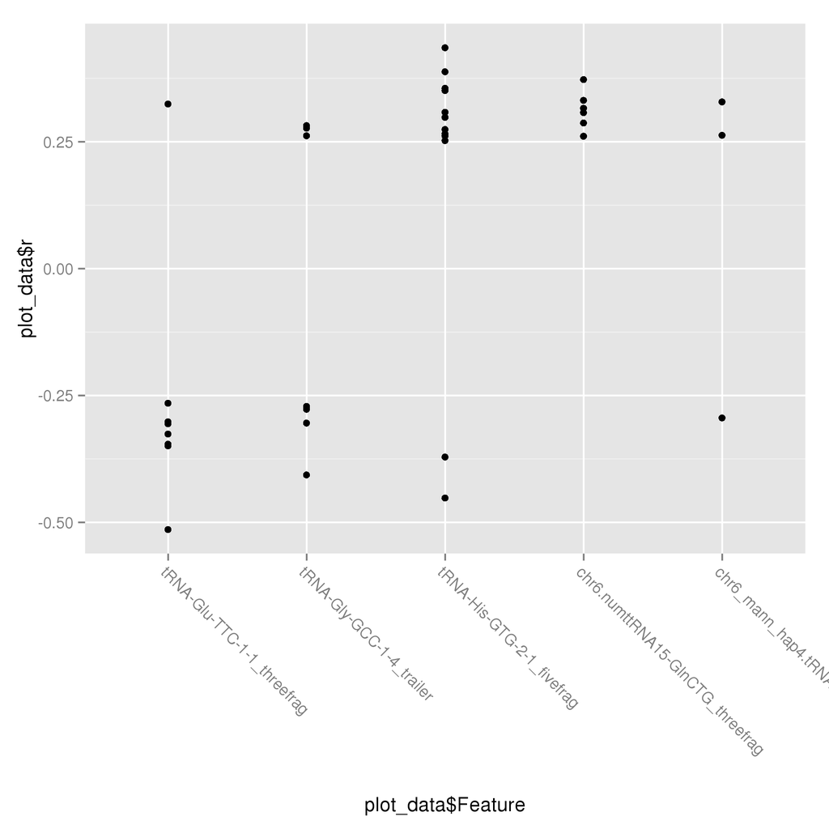

```r
# sample 5 elements, then sample 5 rows with those elements
plot_data <- mir_corr_df[which(mir_corr_df$Feature %in% sample(mir_corr_df$Feature, 5) & (mir_corr_df$r >= 0.25 | mir_corr_df$r <= -0.25)), ]
#plot <- qplot(x = plot_data$Feature, y = plot_data$r, data = plot_data, geom = "point")
plot <- qplot(data = plot_data, x = plot_data$Feature, y = plot_data$r, geom = "point") + theme(axis.text.x = element_text(angle = -45, hjust = 0))
#plot <- ggplot() + geom_point(data = plot_data, aes(x = Feature, y = r)) + theme(axis.text.x = element_text(angle = -45, hjust = 0))#+ geom_line(data = plot_data, aes(x = Feature, y = r)) + geom_text(data = plot_data, aes(x = Feature, y = r, label = miRNA, hjust = 0.2, vjust = 0.2)) +
plot
```

```r
interactive_plot <- plotly()$ggplotly(plot)
```

[interactive chart not shown]

### Selecting key miRNAs

#### Differentially expressed miRNAs identified by Schaefer et al. (2009)

Originally, I used the miRNAs derived from [this paper](http://dx.doi.org/10.1002/ijc.24827), which describes miRNAs dysregulated in prostate carcinoma. This list of miRNAs can be found at `/inside/grotto/blin/trna-markers/feature-counts/prad-mirnas-1.bed`. Four of these are upregulated, and the other five are downregulated.

The problem with this set of miRNAs is that only `hsa-mir-31` survives the purge.

#### Broad GDAC Firehose PRAD T stage miRNAs

Later analyses showed that most of these miRNAs weren't expressed at a high enough level to be correlated with anything at all. Yikes. I'm going to try using [Broad Firehose](http://gdac.broadinstitute.org/runs/analyses__latest/reports/cancer/PRAD/Correlate_Clinical_vs_miRseq/nozzle.html) instead. There are 16 miRNAs negatively correlated with T stage. I don't know what “negatively correlated with lower stage” means in this context - will need to ask someone from Josh's lab to see what's going on.

Actually, there aren't 16 miRNAs. The very first one, [hsa-mir-3676](http://www.mirbase.org/cgi-bin/mirna_entry.pl?acc=MI0016077), is actually a tRF! I'll look into this later. There are 32 sequences associated from the remaining 15 miRNAs - mostly due to 5' and 3' miRNA fragments from the precursor sequence, but also due to +/- strand entries. These sequences are located at `/inside/grotto/blin/trna-markers/feature-counts/prad-mirnas-2.gff`.